# MDA2025-U5-Losungen

```python
import numpy as np
import matplotlib.pyplot as plt
import matplotlib.cm as cm

import warnings
warnings.filterwarnings(action='ignore')
```

## 5. Übungsblatt SoSe 2025

### Exakte Differentialgleichungen

Löse folgende Differentialgleichungen mit dem Verfahren für exakte Differentialgleichungen.

*a)* $(4x+12y+8)y^\prime +2x+4y+2=0$

*b)* $(\mathrm{e}^x+y)y^\prime + \mathrm{e}^xy + \sin(x) = 0$

*c)* $(1+x) y^\prime + y = 1$

*d)* $(1 + x^2) y^\prime = 2xy - (1 + x^2)^2 $

**Hinweis:** Untersuche zuerst ob die DGL die Bedingung für eine exakte Differentialgleichung erfüllt. Falls dies nicht der Fall ist, benutze einen integrierenden Faktor um die DGL in eine exakte DGL zu transformieren.

#### Lösung

*a)*

umstellen auf die Form $y^\prime = - \dfrac{g(x,y)}{h(x,y)}$

$$(4x+12y+8)y^\prime +2x+4y+2=0\; \rightarrow \; y^\prime = -\dfrac{2x+4y+2}{4x+12y+8}$$

überprüfen auf die Bedingung einer exakten DGL: $\dfrac{\partial g(x,y)}{\partial y} = \dfrac{\partial h(x,y)}{\partial x}$

$$\dfrac{\partial g(x,y)}{\partial y} = 4, \; \dfrac{\partial h(x,y)}{\partial x} = 4$$

Da die Bedingung erfüllt ist, wird $g(x,y)$ *unbestimmt* nach $x$ integriert

$$ u(x,y) = \int (2x+4y+2) \mathrm{d}x = x^2+4xy+2x + K(y)$$

Bestimmung von $\dfrac{\partial u(x,y)}{\partial y}$ und mit $h(x,y)$ vergleichen

$$\dfrac{\partial u(x,y)}{\partial y} = 4x + K^\prime(y) = 4x + 12y+ 8, \; \rightarrow \; K^\prime(y) = 12y+8 \; \rightarrow \; K(y) = \int (12y+8) \mathrm{d}y = 6y^2+8y + C$$

Damit ergibt sich als Lösung für $u(x,y) = \mathrm{konstant}$ (in *impliziter* Form)

$$u(x,y) = x^2+4xy+2x + 6y^2+8y + C = 0$$

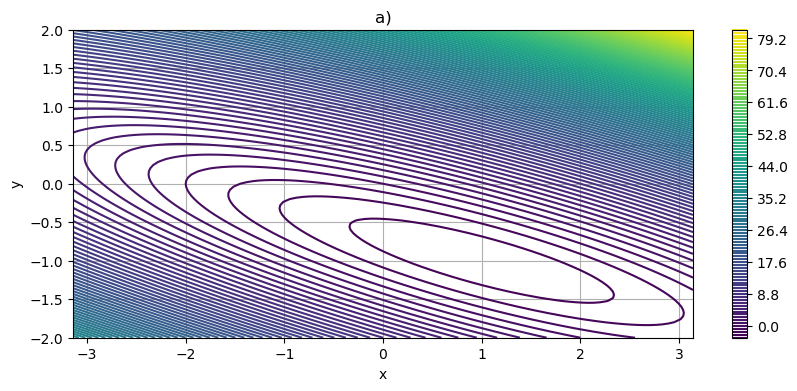

```python
y = np.linspace(-2,2,101)
x = np.linspace(-np.pi, np.pi,101)
X,Y = np.meshgrid(x,y)
U = X*X+4*X*Y+2*X+6*Y*Y+8*Y
fig = plt.figure(figsize=(10,4))
ax = fig.add_subplot(111)
clb = ax.contour(X,Y,U,128)
ax.set_xlabel('x')
ax.set_ylabel('y')
ax.set_title('a)')
ax.grid()
fig.colorbar(clb, ax=ax)
plt.show()
```

*b)*

umstellen auf die Form $y^\prime = - \dfrac{g(x,y)}{h(x,y)}$

$$(\mathrm{e}^x+y)y^\prime + \mathrm{e}^xy + \sin(x) = 0 \; \rightarrow \; y^\prime = -\dfrac{\mathrm{e}^xy + \sin(x)}{\mathrm{e}^x+y}$$

überprüfen auf die Bedingung einer exakten DGL: $\dfrac{\partial g(x,y)}{\partial y} = \dfrac{\partial h(x,y)}{\partial x}$

$$\dfrac{\partial g(x,y)}{\partial y} = \mathrm{e}^x, \; \dfrac{\partial h(x,y)}{\partial x} = \mathrm{e}^x$$

Da die Bedingung erfüllt ist, wird $g(x,y)$ *unbestimmt* nach $x$ integriert

$$ u(x,y) = \int (\mathrm{e}^xy + \sin(x)) \mathrm{d}x = \mathrm{e}^xy - \cos(x) + K(y)$$

Bestimmung von $\dfrac{\partial u(x,y)}{\partial y}$ und mit $h(x,y)$ vergleichen

$$\dfrac{\partial u(x,y)}{\partial y} = \mathrm{e}^x + K^\prime(y) = \mathrm{e}^x+y, \; \rightarrow \; K^\prime(y) = y \; \rightarrow \; K(y) = \int y \mathrm{d}y = \dfrac{1}{2}y^2 + C$$

Damit ergibt sich als Lösung für $u(x,y) = \mathrm{konstant}$ (in *impliziter* Form)

$$u(x,y) = \mathrm{e}^xy - \cos(x) + \dfrac{1}{2}y^2 + C = 0 \; \text{bzw.} \; u(x,y)=\mathrm{e}^xy - \cos(x) + \dfrac{1}{2}y^2 = D$$

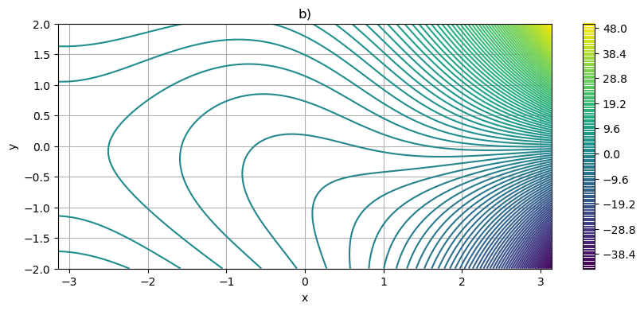

```python
y = np.linspace(-2,2,101)
x = np.linspace(-np.pi, np.pi,101)
X,Y = np.meshgrid(x,y)
U = np.exp(X)*Y - np.cos(X) + 0.5*Y**2
fig = plt.figure(figsize=(10,4))
ax = fig.add_subplot(111)
clb = ax.contour(X,Y,U,128)
ax.set_xlabel('x')
ax.set_ylabel('y')
ax.set_title('b)')
ax.grid()
fig.colorbar(clb, ax=ax)
plt.show()
```

*c)*

Form der exakten DGL $$y^\prime = -\dfrac{y - 1}{1+x} = - \dfrac{g(x,y)}{h(x,y)}$$

Bedingung $$\dfrac{\partial g(x,y)}{\partial y} = 1, \; \dfrac{\partial h(x,y)}{\partial x} = 1$$

Bedingung ist erfüllt!

Integration von $g(x,y)$ $$ u(x,y) = \int (y-1) \mathrm{d}x = (y - 1)x + K(y)$$

Ableitung von $u(x,y)$ nach $y$ und Vergleich mit $h(x,y)$ $$\dfrac{\partial u(x,y)}{\partial y} = x + K^\prime(y) = 1 + x, \; \rightarrow \; K^\prime(y) = 1 \; \rightarrow \; K(y) = \int 1 \mathrm{d}y = y + C$$

Lösung für $u(x,y)$ $$u(x,y) = \mathrm{konstant} = (y - 1)x + y + C\; \rightarrow \; y = \dfrac{D + x}{1+x} $$

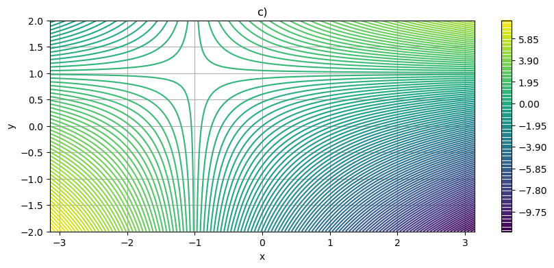

```python
y = np.linspace(-2,2,101)
x = np.linspace(-np.pi, np.pi,101)
X,Y = np.meshgrid(x,y)
U = (Y-1)*X + Y
fig = plt.figure(figsize=(10,4))
ax = fig.add_subplot(111)
clb = ax.contour(X,Y,U,128)
ax.set_xlabel('x')
ax.set_ylabel('y')
ax.set_title('c)')
ax.grid()
fig.colorbar(clb, ax=ax)
plt.show()
```

*d)*

Form der exakten DGL $$y^\prime = -\dfrac{2xy - (1 + x^2)^2}{-1 - x^2} = - \dfrac{g(x,y)}{h(x,y)}$$

Bedingung $$\dfrac{\partial g(x,y)}{\partial y} = 2x, \; \dfrac{\partial h(x,y)}{\partial x} = -2x$$

Bedingung ist **nicht** erfüllt! Benutzung eines integrierenden Faktors der Form $\lambda(x)$

Ansatz $$\dfrac{\partial}{\partial y}\left[\lambda(x) \left(2xy - (1 + x^2)^2\right)\right] = \dfrac{\partial}{\partial x}\left[\lambda(x) \left(-1 - x^2\right)\right] \; \rightarrow \; 2x\lambda(x) = \lambda^\prime(x)\left(-1 - x^2\right) - 2x\lambda(x)$$

umstellen nach $\lambda^\prime(x)$ ergibt $$\lambda^\prime(x) = \dfrac{4x\lambda(x)}{-1 - x^2} = -\dfrac{4x}{1 + x^2}\lambda(x) \; \rightarrow \dfrac{\mathrm{d} \lambda}{\lambda} = -\dfrac{4x}{1 + x^2} \mathrm{d}x$$

auflösen (durch integrieren) nach $\lambda(x)$ führt auf $$ \ln(\lambda(x)) = -4 \cdot \dfrac{1}{2} \cdot \ln(1 + x^2) + \ln(C) = -2 \ln(1 + x^2) + \ln(C) \; \rightarrow \; \lambda(x) = \dfrac{C}{(1+x^2)^2}$$

da $C$ frei wählbar ist, wird $C = 1$ benutzt

Integration von $h(x,y)\cdot \lambda(x)$ (*da einfacher*) $$ u(x,y) = \int \left(-1 - x^2\right)\dfrac{1}{(1+x^2)^2} \mathrm{d}y = -\int \left(1 + x^2\right)\dfrac{1}{(1+x^2)^2} \mathrm{d}y = -\int \dfrac{1}{(1+x^2)} \mathrm{d}y = -\dfrac{y}{1+x^2} + K(x)$$

Ableitung von $u(x,y)$ nach $x$ und Vergleich mit $g(x,y)\cdot \lambda(x)$ $$\dfrac{\partial u(x,y)}{\partial x} = \dfrac{2xy}{(1+x^2)^2} + K^\prime(x) = \dfrac{1}{(1+x^2)^2} \left(2xy - (1 + x^2)^2\right) = \dfrac{2xy}{(1+x^2)^2} - 1, \; \rightarrow \; K^\prime(x) = -1 \; \rightarrow \; K(x) = -\int 1 \mathrm{d}x = -x + C$$

Lösung für $u(x,y)$ $$u(x,y) = \mathrm{konstant} = -\dfrac{y}{1+x^2} -x + C\; \rightarrow \; y = - x^3 + Dx^2 -x + D $$

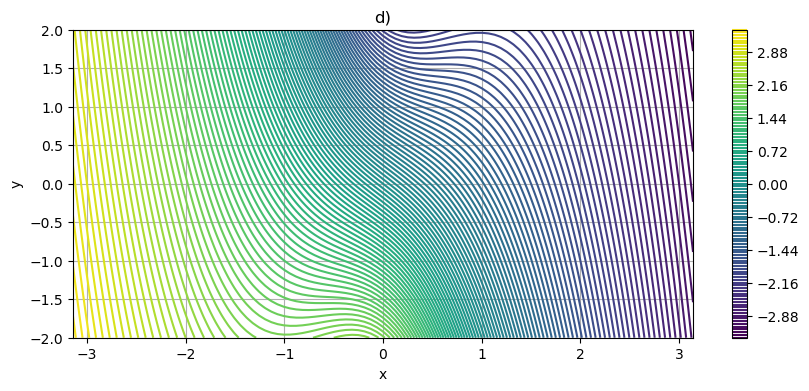

```python
y = np.linspace(-2,2,101)
x = np.linspace(-np.pi, np.pi,101)
X,Y = np.meshgrid(x,y)
U = -Y/(1+X**2) - X
fig = plt.figure(figsize=(10,4))
ax = fig.add_subplot(111)
clb = ax.contour(X,Y,U,128)
ax.set_xlabel('x')
ax.set_ylabel('y')
ax.set_title('d)')
ax.grid()
fig.colorbar(clb, ax=ax)
plt.show()
```